# A Bayesian workflow with nimbleNeonorm

This vignette fits a skewed location-scale model with the MSNBurr and MSNBurr-IIa distributions, following the steps of the Bayesian workflow of Gelman et al. (2020): specify the model and its priors, check the priors through the data they imply, validate the computation on simulated data with known parameters, check convergence, check the fit against the data, and compare models.

```r
library(nimbleNeonorm)
register_neonorm(verbose = FALSE)
```

## 1. The distributions

Both distributions have a location `mu`, a scale `sigma` and a shape `alpha` (Choir, 2020; Ramadani et al., 2025). Their mode is `mu`, where the density equals that of a normal distribution with standard deviation `sigma`. With `alpha = 1` both are symmetric. MSNBurr is skewed to the left for `alpha < 1` and to the right for `alpha > 1`; MSNBurr-IIa, its mirror image about `mu`, does the opposite.

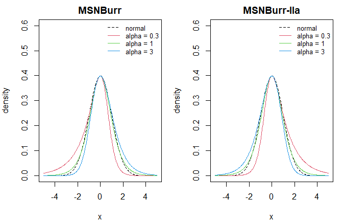

```r
x <- seq(-5, 5, length.out = 401)
dens <- function(f, a) vapply(x, f, numeric(1), mu = 0, sigma = 1, alpha = a)
alphas <- c(0.3, 1, 3)

op <- par(mfrow = c(1, 2), mar = c(4, 4, 2, 1))
for (fam in c("MSNBurr", "MSNBurr-IIa")) {
  f <- if (fam == "MSNBurr") dmsnburr else dmsnburr2a
  plot(x, dnorm(x), type = "l", lty = 2, ylim = c(0, 0.6),
       xlab = "x", ylab = "density", main = fam)
  for (k in seq_along(alphas)) lines(x, dens(f, alphas[k]), col = k + 1)
  legend("topright", c("normal", paste("alpha =", alphas)),
         lty = c(2, 1, 1, 1), col = c(1, 2:4), bty = "n", cex = 0.8)
}
```

```r
par(op)
```

## 2. Model and priors

We model `N` observations as independent draws from MSNBurr-IIa. The priors are weakly informative for data on a unit scale, so the data should be standardised (or the priors rescaled) before fitting:

- `mu ~ Normal(0, 5)`: the location lies within a few units of zero.
- `sigma ~ Exponential(1)`: a proper prior on the scale that favours moderate values without excluding large ones (Gelman, 2006).
- `alpha ~ LogNormal(0, 1)`: its median, 1, is the symmetric case, and it treats skewness in either direction alike on the log scale; 95% of its mass lies between about 0.14 and 7.1.

```r
model_code <- list(
  normal = nimbleCode({
    for (i in 1:N) y[i] ~ dnorm(mu, sd = sigma)
    mu ~ dnorm(0, sd = 5)
    sigma ~ dexp(1)
  }),
  msnburr = nimbleCode({
    for (i in 1:N) y[i] ~ dmsnburr(mu, sigma, alpha)
    mu ~ dnorm(0, sd = 5)
    sigma ~ dexp(1)
    alpha ~ dlnorm(0, sdlog = 1)
  }),
  msnburr2a = nimbleCode({
    for (i in 1:N) y[i] ~ dmsnburr2a(mu, sigma, alpha)
    mu ~ dnorm(0, sd = 5)
    sigma ~ dexp(1)
    alpha ~ dlnorm(0, sdlog = 1)
  })
)

make_model <- function(family, y) {
  inits <- list(mu = 0, sigma = 1)
  if (family != "normal") inits$alpha <- 1
  nimbleModel(
    model_code[[family]],
    constants = list(N = length(y)),
    data = list(y = y),
    inits = inits
  )
}
```

## 3. Prior predictive check

Before looking at any data, we simulate parameters from the priors and data from the likelihood, and ask whether the implied data are plausible (Gelman et al., 2020, Section 2.4; Gabry et al., 2019).

```r
n <- 200
prior_model <- make_model("msnburr2a", y = rep(0, n))
```

```
#> Defining model
#> Building model
#> Setting data and initial values
#> Running calculate on model
#>   [Note] Any error reports that follow may simply reflect missing values in model variables.
#> Checking model sizes and dimensions
```

```r
prior <- prior_predict_neonorm(prior_model, nsim = 200, seed = 1)

# Spread of each simulated data set
prior_range <- apply(prior$data, 1, function(d) diff(range(d)))
summary(prior_range)
```

```
#>     Min.  1st Qu.   Median     Mean  3rd Qu.     Max.
#>  0.00402  2.09555  4.67753  6.94517  9.85917 44.85661
```

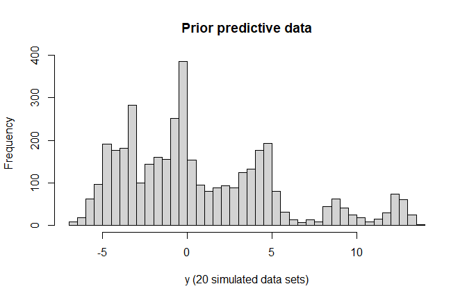

```r
hist(prior$data[1:20, ], breaks = 60, main = "Prior predictive data",
     xlab = "y (20 simulated data sets)")
```

For standardised data, most simulated data sets should span a few to a few tens of units, with only a small fraction far more extreme. If many simulated data sets were implausible for the application, the priors would need to be tightened before fitting; if they were all nearly identical, the priors would be too restrictive.

## 4. Validating the computation on simulated data

To check that the model and the software recover known parameters, we simulate data with known values and fit the model to them (Cook et al., 2006; Gelman et al., 2020, Section 4.1).

```r
true <- c(mu = 0, sigma = 1, alpha = 0.3)   # clearly right-skewed
set.seed(2026)
y <- replicate(n, rmsnburr2a(1, true[["mu"]], true[["sigma"]],
                             true[["alpha"]]))

fit <- runmcmc_neonorm(
  make_model("msnburr2a", y),
  niter = 4000,
  nchains = 4,
  sampler = "slice",
  WAIC = TRUE
)
```

[output not shown]

```r
fit
```

```
#> nimbleNeonorm MCMC fit: 4 chain(s), 4000 iterations (2000 burn-in, thin = 1), sampler = "slice"
#>
#>         Mean    SD   2.5%    50% 97.5%  Rhat ESS_bulk ESS_tail
#> alpha  0.368 0.076  0.243  0.360 0.538 1.003  984.183 1867.653
#> mu    -0.093 0.110 -0.307 -0.094 0.127 1.004  691.958  977.211
#> sigma  0.989 0.063  0.876  0.986 1.120 1.002 1504.710 1841.791
#>
#> WAIC = 640.5  (pWAIC = 2.69)
```

`runmcmc_neonorm()` starts the four chains from different draws of the prior (`prior_inits_neonorm()`), so that $\hat{R}$ can detect chains that have not mixed. The slice sampler is used for `alpha` because it needs no proposal scale (Neal, 2003).

```r
recovery <- cbind(true = true,
                  fit$summary[names(true), c("Mean", "2.5%", "97.5%")])
round(recovery, 3)
```

```
#>       true   Mean   2.5% 97.5%
#> mu     0.0 -0.093 -0.307 0.127
#> sigma  1.0  0.989  0.876 1.120
#> alpha  0.3  0.368  0.243 0.538
```

The true values should lie inside their 95% credible intervals, and the posterior means should be close to them. A single data set is only a sanity check, since a 95% interval misses the truth 5% of the time; the repeated-simulation study in the package repository (`analysis/simulation-study.R`) estimates bias, mean squared error and interval coverage over many data sets.

## 5. Convergence diagnostics

The summary reports the rank-normalised split-$\hat{R}$ and the bulk and tail effective sample sizes of Vehtari et al. (2021). They recommend $\hat{R} < 1.01$ and ESS above 100 per chain; `summarise_neonorm()` warns otherwise. Trace plots complement these numbers.

```r
fit$summary[, c("Rhat", "ESS_bulk", "ESS_tail")]
```

```
#>           Rhat  ESS_bulk  ESS_tail
#> alpha 1.002907  984.1834 1867.6526
#> mu    1.003934  691.9576  977.2111
#> sigma 1.002103 1504.7098 1841.7910
```

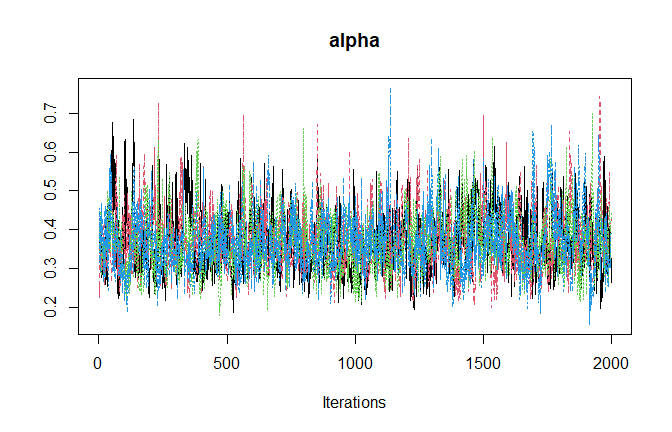

```r
coda::traceplot(fit$samples[, "alpha"], main = "alpha")
```

## 6. Posterior predictive check

We simulate replicated data sets from the fitted model and compare them with the observed data, both visually and through a test statistic, the sample skewness (Gelman et al., 2013, Chapter 6; Gabry et al., 2019).

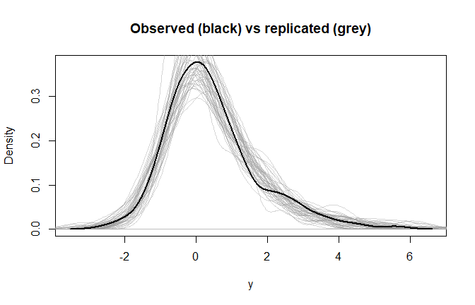

```r
yrep <- posterior_predict_neonorm(fit, ndraws = 200, seed = 1)

plot(density(y), lwd = 2, main = "Observed (black) vs replicated (grey)",
     xlab = "y")
for (i in 1:50) lines(density(yrep[i, ]), col = grDevices::gray(0.6, 0.4))
lines(density(y), lwd = 2)
```

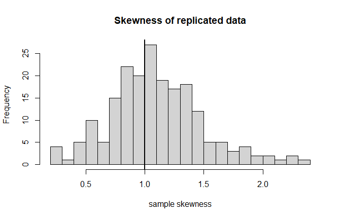

```r
skewness <- function(v) mean((v - mean(v))^3) / stats::sd(v)^3
t_obs <- skewness(y)
t_rep <- apply(yrep, 1, skewness)
hist(t_rep, breaks = 30, main = "Skewness of replicated data",
     xlab = "sample skewness")
abline(v = t_obs, lwd = 2)
```

```r
mean(t_rep >= t_obs)   # posterior predictive p-value
```

```
#> [1] 0.59
```

A posterior predictive p-value far from 0 and 1 means the model reproduces the skewness of the data.

## 7. Model comparison

Finally, we fit the normal and MSNBurr models to the same data and compare the three with WAIC (Watanabe, 2010; Vehtari et al., 2017); lower is better.

```r
fits <- list(
  normal = runmcmc_neonorm(make_model("normal", y), niter = 4000,
                           WAIC = TRUE),
  msnburr = runmcmc_neonorm(make_model("msnburr", y), niter = 4000,
                            sampler = "slice", WAIC = TRUE),
  msnburr2a = fit
)
```

[output not shown]

[output cut: 9 more lines]

[output not shown]

```r
waic <- vapply(fits, function(f) f$WAIC$WAIC, numeric(1))
sort(waic)
```

```
#> msnburr2a   msnburr    normal
#>  640.4996  643.8369  673.8342
```

The data were generated from MSNBurr-IIa with a strong right skew, which MSNBurr-IIa accommodates most easily (Ramadani et al., 2025), so we expect it to have the lowest WAIC and the normal model, which cannot represent skewness, the highest. Differences of a few units of WAIC are within its sampling uncertainty (Vehtari et al., 2017).

```r
cleanup_neonorm(verbose = FALSE)
```

```
#> Deregistering 'dmsnburr, dmsnburr2a' from user-registered distributions.
```

## References

Choir, A. S. (2020). *Distribusi neo-normal baru dan karakteristiknya* [Doctoral dissertation]. Institut Teknologi Sepuluh Nopember.

Cook, S. R., Gelman, A., & Rubin, D. B. (2006). Validation of software for Bayesian models using posterior quantiles. *Journal of Computational and Graphical Statistics*, 15(3), 675–692. https://doi.org/10.1198/106186006X136976

Gabry, J., Simpson, D., Vehtari, A., Betancourt, M., & Gelman, A. (2019). Visualization in Bayesian workflow. *Journal of the Royal Statistical Society: Series A*, 182(2), 389–402. https://doi.org/10.1111/rssa.12378

Gelman, A. (2006). Prior distributions for variance parameters in hierarchical models. *Bayesian Analysis*, 1(3), 515–534. https://doi.org/10.1214/06-BA117A

Gelman, A., Carlin, J. B., Stern, H. S., Dunson, D. B., Vehtari, A., & Rubin, D. B. (2013). *Bayesian Data Analysis* (3rd ed.). CRC Press.

Gelman, A., Vehtari, A., Simpson, D., Margossian, C. C., Carpenter, B., Yao, Y., Kennedy, L., Gabry, J., Bürkner, P.-C., & Modrák, M. (2020). *Bayesian workflow*. arXiv:2011.01808. https://doi.org/10.48550/arXiv.2011.01808

Neal, R. M. (2003). Slice sampling. *The Annals of Statistics*, 31(3), 705–767. https://doi.org/10.1214/aos/1056562461

Ramadani, E. P., Choir, A. S., Pravitasari, A. A., & Paraguison, J. (2025). Adding MSNBURR-IIa distribution to MultiBUGS. *Jurnal Aplikasi Statistika & Komputasi Statistik*, 17(2), 109–130. https://doi.org/10.34123/jurnalasks.v17i2.804

Vehtari, A., Gelman, A., & Gabry, J. (2017). Practical Bayesian model evaluation using leave-one-out cross-validation and WAIC. *Statistics and Computing*, 27(5), 1413–1432. https://doi.org/10.1007/s11222-016-9696-4

Vehtari, A., Gelman, A., Simpson, D., Carpenter, B., & Bürkner, P.-C. (2021). Rank-normalization, folding, and localization: An improved $\hat{R}$ for assessing convergence of MCMC. *Bayesian Analysis*, 16(2), 667–718. https://doi.org/10.1214/20-BA1221

Watanabe, S. (2010). Asymptotic equivalence of Bayes cross validation and widely applicable information criterion in singular learning theory. *Journal of Machine Learning Research*, 11, 3571–3594.